# Part I - Prosper Loan Data Analysis

## Introduction

### Dataset Introduction

Prosper is a peer-to-peer (P2P) lending company, which facilitates loans between individual borrowers and investors. Founded in 2005, Prosper Marketplace, Inc. is headquartered in San Francisco, California. The company operates an online platform where borrowers can apply for personal loans and investors can fund those loans, earning interest on their investments.

This dataset, provided by Prosper, contains 113,937 loans with 81 variables for each loan, including loan amount, borrower rate (or interest rate), current loan status, borrower income, and many others

## Preliminary Wrangling

### Importing Necessary Packages and Loading Data

Before diving into the analysis, we need to ensure we have the right tools and data at our disposal. This involves importing essential libraries and loading our dataset. Let's walk through the process step by step.

To begin, we import a set of powerful Python libraries that will help us manipulate data, perform numerical computations, and create visualizations:

```python
# import all packages and set plots to be embedded inline
import numpy as np
import pandas as pd
import matplotlib.pyplot as plt
from matplotlib.ticker import FuncFormatter
import seaborn as sns
```

With our libraries imported, the next step is to load the dataset we'll be working with. The dataset, named prosperLoanData.csv, contains information about loans issued by Prosper, a peer-to-peer lending company.

After loading the data, we display the first few rows to get an initial understanding of what the dataset looks like

```python
# Load the dataset from the CSV file into a pandas DataFrame
df_raw = pd.read_csv('prosperLoanData.csv')

# Display the first few rows of the DataFrame to get an overview of the data
df_raw.head()
```

|  | ListingKey | ListingNumber | ListingCreationDate | CreditGrade | Term | LoanStatus | ClosedDate | BorrowerAPR | BorrowerRate | LenderYield | ... | LP_ServiceFees | LP_CollectionFees | LP_GrossPrincipalLoss | LP_NetPrincipalLoss | LP_NonPrincipalRecoverypayments | PercentFunded | Recommendations | InvestmentFromFriendsCount | InvestmentFromFriendsAmount | Investors |
| --- | --- | --- | --- | --- | --- | --- | --- | --- | --- | --- | --- | --- | --- | --- | --- | --- | --- | --- | --- | --- | --- |
| 0 | 1021339766868145413AB3B | 193129 | 2007-08-26 19:09:29.263000000 | C | 36 | Completed | 2009-08-14 00:00:00 | 0.16516 | 0.1580 | 0.1380 | ... | -133.18 | 0.0 | 0.0 | 0.0 | 0.0 | 1.0 | 0 | 0 | 0.0 | 258 |
| 1 | 10273602499503308B223C1 | 1209647 | 2014-02-27 08:28:07.900000000 | NaN | 36 | Current | NaN | 0.12016 | 0.0920 | 0.0820 | ... | 0.00 | 0.0 | 0.0 | 0.0 | 0.0 | 1.0 | 0 | 0 | 0.0 | 1 |
| 2 | 0EE9337825851032864889A | 81716 | 2007-01-05 15:00:47.090000000 | HR | 36 | Completed | 2009-12-17 00:00:00 | 0.28269 | 0.2750 | 0.2400 | ... | -24.20 | 0.0 | 0.0 | 0.0 | 0.0 | 1.0 | 0 | 0 | 0.0 | 41 |
| 3 | 0EF5356002482715299901A | 658116 | 2012-10-22 11:02:35.010000000 | NaN | 36 | Current | NaN | 0.12528 | 0.0974 | 0.0874 | ... | -108.01 | 0.0 | 0.0 | 0.0 | 0.0 | 1.0 | 0 | 0 | 0.0 | 158 |
| 4 | 0F023589499656230C5E3E2 | 909464 | 2013-09-14 18:38:39.097000000 | NaN | 36 | Current | NaN | 0.24614 | 0.2085 | 0.1985 | ... | -60.27 | 0.0 | 0.0 | 0.0 | 0.0 | 1.0 | 0 | 0 | 0.0 | 20 |

5 rows × 81 columns

The table shows 5 rows and 81 columns, providing a snapshot of the dataset. Each row represents a unique loan, and the columns contain various attributes related to the loan and borrower.

### Refining the Dataset for Analysis

To conduct a meaningful analysis, Let's refine and focus the dataset by selecting relevant columns. This step helps in reducing the complexity of the dataset and zooming in on the attributes that are most pertinent to our research questions.

```python
# Create a new DataFrame with selected columns from the original DataFrame
df_raw_v2 = df_raw[['ListingKey', 'Term', 'BorrowerRate', 'ProsperRating (Alpha)', 'IsBorrowerHomeowner', 'CreditScoreRangeLower', 'CreditScoreRangeUpper']]
```

```python
# Display the shape of the DataFrame df_raw_v2
df_raw_v2.shape
```

```
(113937, 7)
```

Our dataset contains 113,937 records and 7 columns (variables). Each row represents a unique loan, and each column provides specific information about that loan.

```python
# Display the first few rows of the new DataFrame to verify the selected columns
df_raw_v2.head()
```

|  | ListingKey | Term | BorrowerRate | ProsperRating (Alpha) | IsBorrowerHomeowner | CreditScoreRangeLower | CreditScoreRangeUpper |
| --- | --- | --- | --- | --- | --- | --- | --- |
| 0 | 1021339766868145413AB3B | 36 | 0.1580 | NaN | True | 640.0 | 659.0 |
| 1 | 10273602499503308B223C1 | 36 | 0.0920 | A | False | 680.0 | 699.0 |
| 2 | 0EE9337825851032864889A | 36 | 0.2750 | NaN | False | 480.0 | 499.0 |
| 3 | 0EF5356002482715299901A | 36 | 0.0974 | A | True | 800.0 | 819.0 |
| 4 | 0F023589499656230C5E3E2 | 36 | 0.2085 | D | True | 680.0 | 699.0 |

#### Variables Overview

The variables shown in the table above provide a comprehensive snapshot of each loan and borrower, allowing us to explore various aspects of the lending process. By examining factors such as loan term, borrower rate, credit rating, and homeownership status, we can gain valuable insights into the dynamics of peer-to-peer lending on Prosper.

- **ListingKey**: A unique identifier for each loan listing.
- **Term**: The loan term in months (e.g., 36 or 60 months).
- **BorrowerRate**: The interest rate charged to the borrower.
- **ProsperRating (Alpha)**: A proprietary credit rating assigned by Prosper, ranging from AA (lowest risk) to HR (highest risk).
- **IsBorrowerHomeowner**: A boolean indicating whether the borrower is a homeowner.
- **CreditScoreRangeLower**: The lower bound of the borrower’s credit score range.
- **CreditScoreRangeUpper**: The upper bound of the borrower’s credit score range.

### Removing Duplicate Records

First, we need to determine if there are any duplicate records in our dataset. Specifically, we are interested in duplicates based on the ListingKey, which is a unique identifier for each loan listing.

```python
# Check for duplicate records based on the 'ListingKey' column in df_raw_v2
df_raw_v2.duplicated(['ListingKey']).sum()
```

```
871
```

There are 871 duplicate rows. The next step is to remove them. We create a new DataFrame, df_raw_v3, which contains only unique entries by dropping the duplicates.

```python
# Remove duplicate records based on the 'ListingKey' column and create a new DataFrame df_raw_v3
df_raw_v3 = df_raw_v2.drop_duplicates(subset=['ListingKey'])
```

Finally, we verify that the duplicates have been successfully removed by checking for any remaining duplicates in the new DataFrame.

```python
# Verify that there are no duplicate records left in df_raw_v3 based on the 'ListingKey' column
df_raw_v3.duplicated(['ListingKey']).sum()
```

```
0
```

Great! No more duplicate rows.

### Handling Missing Values

First, we need to identify how many missing values are present in each column of our dataset. This gives us an overview of the data completeness and helps us decide on the best approach to handle these gaps.

```python
# Check for missing values in each column of df_raw_v3
df_raw_v3.isna().sum()
```

```
ListingKey                   0
Term                         0
BorrowerRate                 0
ProsperRating (Alpha)    29084
IsBorrowerHomeowner          0
CreditScoreRangeLower      591
CreditScoreRangeUpper      591
dtype: int64
```

To ensure our analysis is based on complete data, we remove all rows that contain any missing values. This step results in a new DataFrame, df_raw_v4, which contains only complete records.

```python
# Remove rows with any missing values and create a new DataFrame df_raw_v4
df_raw_v4 = df_raw_v3.dropna()

# Reset the index of df_raw_v4 to maintain a clean index after dropping rows
df_raw_v4 = df_raw_v4.reset_index(drop=True)

# Check for missing values in each column of df_raw_v4
df_raw_v4.isna().sum()
```

```
ListingKey               0
Term                     0
BorrowerRate             0
ProsperRating (Alpha)    0
IsBorrowerHomeowner      0
CreditScoreRangeLower    0
CreditScoreRangeUpper    0
dtype: int64
```

Great! The absence of missing values confirmed that our dataset was now complete and ready for further analysis.

### Calculating Average Credit Scores

As we continue to refine our dataset, the next step is to enhance the usability of our data by calculating the average credit score for each borrower. This process simplifies the analysis by providing a single, representative credit score value for each borrower, rather than a range.

First, we inspect the current structure and contents of our cleaned dataset, df_raw_v4, to understand its columns and data types.

```python
# Display the structure and data types of df_raw_v4
df_raw_v4.info()
```

```
<class 'pandas.core.frame.DataFrame'>
RangeIndex: 83982 entries, 0 to 83981
Data columns (total 7 columns):
 #   Column                 Non-Null Count  Dtype
---  ------                 --------------  -----
 0   ListingKey             83982 non-null  object
 1   Term                   83982 non-null  int64
 2   BorrowerRate           83982 non-null  float64
 3   ProsperRating (Alpha)  83982 non-null  object
 4   IsBorrowerHomeowner    83982 non-null  bool
 5   CreditScoreRangeLower  83982 non-null  float64
 6   CreditScoreRangeUpper  83982 non-null  float64
dtypes: bool(1), float64(3), int64(1), object(2)
memory usage: 3.9+ MB
```

Borrowers in our dataset have credit scores represented by a range, with **CreditScoreRangeLower** and **CreditScoreRangeUpper** indicating the lower and upper bounds of their credit scores, respectively. To simplify our analysis, we calculate the average credit score for each borrower.

```python
# Calculate the average credit score and create a new column 'CreditScore'
df_raw_v4['CreditScore'] = ((df_raw_v4['CreditScoreRangeLower'] + df_raw_v4['CreditScoreRangeUpper']) / 2).astype(int)
```

With the average credit score calculated and stored in the **CreditScore column**, the original **CreditScoreRangeLower** and **CreditScoreRangeUpper** columns are no longer needed. We drop these columns to streamline our dataset.

```python
# Drop the original credit score range columns
df_raw_v5 = df_raw_v4.drop(['CreditScoreRangeLower', 'CreditScoreRangeUpper'], axis=1)
```

Finally, we inspect the structure of the updated dataset, df_raw_v5, to ensure that the changes have been applied correctly.

```python
# Display the structure and data types of df_raw_v5
df_raw_v5.info()
```

```
<class 'pandas.core.frame.DataFrame'>
RangeIndex: 83982 entries, 0 to 83981
Data columns (total 6 columns):
 #   Column                 Non-Null Count  Dtype
---  ------                 --------------  -----
 0   ListingKey             83982 non-null  object
 1   Term                   83982 non-null  int64
 2   BorrowerRate           83982 non-null  float64
 3   ProsperRating (Alpha)  83982 non-null  object
 4   IsBorrowerHomeowner    83982 non-null  bool
 5   CreditScore            83982 non-null  int64
dtypes: bool(1), float64(1), int64(2), object(2)
memory usage: 3.3+ MB
```

By calling the info() method again, we verify that the **CreditScore** column has been added and the original credit score range columns have been removed.

### Creating a Clean Dataset

As we move forward in our analysis, the next step is to create a working copy of our refined dataset. This ensures that we preserve the original cleaned data while allowing us to perform various transformations and analyses on a separate copy.

First, we create a copy of our refined dataset, df_raw_v5, to work with. This copy will be named df_clean.

```python
# Create a working copy of the refined dataset
df_clean = df_raw_v5.copy()
```

Next, we take a look at the first few rows of df_clean to get an initial sense of the data and ensure that everything looks as expected.

```python
# Display the first few rows of the clean dataset
df_clean.head()
```

|  | ListingKey | Term | BorrowerRate | ProsperRating (Alpha) | IsBorrowerHomeowner | CreditScore |
| --- | --- | --- | --- | --- | --- | --- |
| 0 | 10273602499503308B223C1 | 36 | 0.0920 | A | False | 689 |
| 1 | 0EF5356002482715299901A | 36 | 0.0974 | A | True | 809 |
| 2 | 0F023589499656230C5E3E2 | 36 | 0.2085 | D | True | 689 |
| 3 | 0F05359734824199381F61D | 60 | 0.1314 | B | True | 749 |
| 4 | 0F0A3576754255009D63151 | 36 | 0.2712 | E | False | 689 |

To gain a deeper understanding of our dataset, we use the describe() method to generate summary statistics for each numerical column in df_clean.

```python
# Generate summary statistics for the clean dataset
df_clean.describe()
```

|  | Term | BorrowerRate | CreditScore |
| --- | --- | --- | --- |
| count | 83982.000000 | 83982.00000 | 83982.000000 |
| mean | 42.462813 | 0.19630 | 708.476316 |
| std | 11.639032 | 0.07475 | 47.185610 |
| min | 12.000000 | 0.04000 | 609.000000 |
| 25% | 36.000000 | 0.13590 | 669.000000 |
| 50% | 36.000000 | 0.18750 | 709.000000 |
| 75% | 60.000000 | 0.25740 | 729.000000 |
| max | 60.000000 | 0.36000 | 889.000000 |

```python
# Save the DataFrame to a CSV file
df_clean.to_csv('df_clean.csv', index=False)
```

With a clean, well-understood dataset in hand, we are now ready to dive deeper into our analysis. This foundational work ensures that our subsequent analysis is based on reliable, well-prepared data, setting the stage for robust and insightful findings.

### What is the structure of the dataset?

The cleaned dataset consists of 83,982 records, each representing a unique loan listing. The dataset includes the following key variables that provide a detailed overview of each loan and borrower.

1. **ListingKey**
- Type: String
- Description: A unique identifier for each loan listing.
2. **Term**
- Type: Integer
- Description: The loan term in months (e.g., 12, 36 or 60 months).
3. **BorrowerRate**
- Type: Float
- Description: The interest rate charged to the borrower.
4. **ProsperRating (Alpha)**
- Type: String
- Description: A proprietary credit rating assigned by Prosper, ranging from AA (lowest risk) to HR (highest risk).
5. **IsBorrowerHomeowner**
- Type: Boolean
- Description: A boolean indicating whether the borrower is a homeowner.
6. **CreditScore**
- Type: Integer
- Description: The average credit score of the borrower.

### What are the main features of interest in the dataset?

- **BorrowerRate**: Understanding the factors that influence the borrower rate is crucial. This includes examining how borrower characteristics such as credit score, homeownership status affect the interest rate.
- **ProsperRating (Alpha)**: The Prosper Rating is a key indicator of borrower creditworthiness and loan risk. Analyzing how this rating correlates with other borrower characteristics sich as howmownership status can help in understanding the effectiveness of this rating system in predicting loan performance.
- **IsBorrowerHomeowner**: Homeownership can significantly impact a borrower’s financial stability and creditworthiness. Analyzing the differences in loan terms and borrower rates between homeowners and non-homeowners can reveal important trends and risk factors.

### What features in the dataset will help support the investigation into the features of interest?

- **CreditScore** impacts key features like BorrowerRate and ProsperRating. Higher credit scores typically lead to lower interest rates and better ProsperRatings. Analyzing CreditScore also reveals the impact of homeownership on creditworthiness, showing homeowners often have better scores.
- **Term** influences BorrowerRate due to risk associated with longer durations, often resulting in higher rates. It also affects ProsperRating, as longer terms may be riskier. Examining Term alongside IsBorrowerHomeowner helps understand homeowners' preferences for loan durations and their financial stability.

## Univariate Exploration

### Question

- How is the distribution of loans by term length (in months) in the Prosper loan dataset?

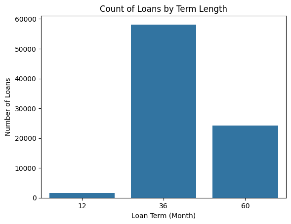

```python
# Creating the count plot
sns.countplot(data=df_clean, x='Term', color='tab:blue')

# Adding labels and title
plt.xlabel('Loan Term (Month)')
plt.ylabel('Number of Loans')
plt.title('Count of Loans by Term Length');
```

### Observation

- The count plot shows that the majority of loans have a term length of 36 months, followed by 60 months, and a small number of loans with a term length of 12 months.
- There are significantly more loans with a 36-month term compared to the other term lengths, indicating a preference for medium-term loans.
- The low count of 12-month loans suggests that borrowers are less inclined to take shorter-term loans, possibly due to higher monthly payments despite lower total interest costs.
- The substantial number of 60-month loans indicates that some borrowers are comfortable with longer-term commitments, which spread the payments over a longer period, reducing the monthly burden but increasing the total interest paid.

### Question

- What is the distribution of Borrower Rates in the dataset?

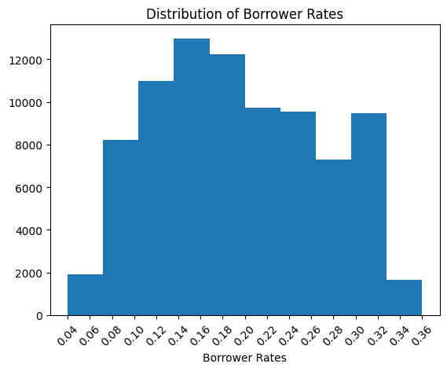

```python
# Create a histogram of Borrower Rates
plt.hist(data=df_clean, x='BorrowerRate', color='tab:blue')

# Set the x-label and title
plt.xlabel('Borrower Rates')
plt.title('Distribution of Borrower Rates')

# Define tick marks for x-axis and rotate them for better readability
ticks_1 = np.arange(df_clean['BorrowerRate'].min(), df_clean['BorrowerRate'].max() + 0.02, 0.02)
plt.xticks(ticks_1, rotation=45);
```

### Observation

- The histogram shows the distribution of Borrower Rates for the dataset, ranging from approximately 0.04 to 0.36.
- The borrower rates are not uniformly distributed; there are noticeable peaks indicating that certain rates are more common among borrowers.
- Most borrower rates appear to be clustered around specific values, with significant frequencies observed between 0.10 and 0.26.

### Question

- What is the distribution of Prosper Ratings among the loans in the dataset?

```python
# Define and order Prosper Rating categories
rating_classes = ['AA', 'A', 'B', 'C', 'D', 'E', 'HR']
rclasses = pd.CategoricalDtype(ordered=True, categories=rating_classes)
df_clean['ProsperRating (Alpha)'] = df_clean['ProsperRating (Alpha)'].astype(rclasses)
```

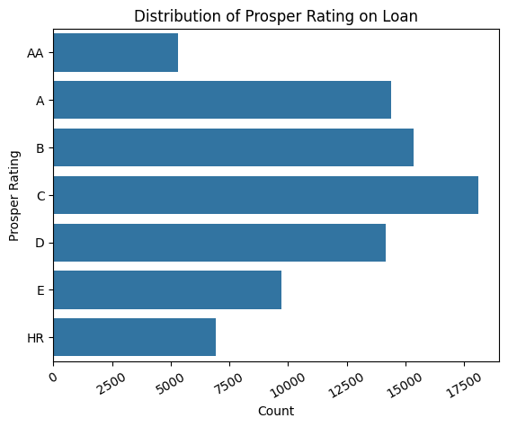

```python
# Create the count plot
sns.countplot(data=df_clean, y='ProsperRating (Alpha)', color='tab:blue')
plt.ylabel('Prosper Rating')
plt.xlabel('Count')
plt.title('Distribution of Prosper Rating on Loan')
plt.xticks(rotation=30);
```

### Observation

- Distribution of Ratings: The count plot reveals that the distribution of loans varies significantly across different Prosper Ratings.
- Most Common Ratings: The most common Prosper Ratings are 'A', 'B', 'C' and 'D'
- Least Common Ratings: The least common Prosper Ratings are 'AA' and 'HR', suggesting that very low-risk and very high-risk loans are less frequent on the Prosper platform.

### Question

- How is the borrower homeowner status distributed among the loans in our dataset?

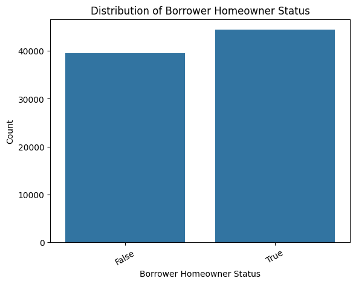

```python
# Create a count plot to visualize the distribution of borrower homeowner status
sns.countplot(data=df_clean, x='IsBorrowerHomeowner', color='tab:blue')

# Set the label for the x-axis
plt.xlabel('Borrower Homeowner Status')

# Set the label for the y-axis
plt.ylabel('Count')

# Set the title of the plot
plt.title('Distribution of Borrower Homeowner Status')

# Rotate the x-axis labels for better readability
plt.xticks(rotation=30);
```

### Observation

- The count plot shows the distribution of borrower homeowner status, with two bars representing the counts of non-homeowners (False) and homeowners (True).
- The plot indicates that there are slightly more homeowners than non-homeowners in the dataset, with both categories having a substantial number of borrowers.
- This visualization helps in understanding the proportion of borrowers who own homes compared to those who do not, which is crucial for analyzing loan characteristics and borrower risk profiles.
- The relatively balanced distribution suggests that the dataset can provide insights into how homeownership status affects borrowing behavior and loan performance.

### Question

What is the distribution of credit scores among the borrowers in the dataset?

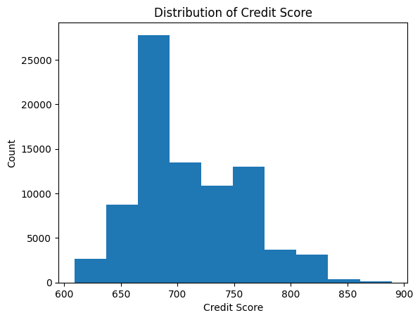

```python
# Plotting a histogram to visualize the distribution of credit scores in the dataset
plt.hist(data=df_clean, x='CreditScore')

# Labeling the x-axis as 'Credit Score'
plt.xlabel('Credit Score')

# Labeling the y-axis as 'Count' to show the number of occurrences
plt.ylabel('Count')

# Adding a title to the histogram to describe the visualization
plt.title('Distribution of Credit Score');
```

### Observation

- The histogram shows that the majority of borrowers have credit scores concentrated between 650 and 775.
- There is a noticeable peak around the 675-700 range, indicating that many borrowers fall within this credit score range.
- There are significantly fewer borrowers with credit scores above 800, and not many below 650.
- The distribution has a right skew, with a longer tail extending towards higher credit scores, indicating a few borrowers with exceptionally high credit scores.

### Unusual Points & Transformations

Overall, the distributions of the variables of interest were as expected, with typical patterns observed in loan datasets. The absence of unusual points in these distributions indicates a clean and consistent dataset. In the data wrangling stage, we transformed the **CreditScore** data by averaging the **CreditScoreRangeLower** and **CreditScoreRangeUpper** into a single **CreditScore** column to simplify analysis. This provided a straightforward measure of creditworthiness, enhanced interpretability, and reduced dataset complexity. The transformation made it easier to visualize and compare credit scores, enabling more efficient and insightful analysis of borrower behavior and loan performance.

## Bivariate Exploration

Display the first few rows of the clean dataset to get an initial overview

```python
# Display the first few rows of the clean dataset to get an initial overview
df_clean.head()
```

|  | ListingKey | Term | BorrowerRate | ProsperRating (Alpha) | IsBorrowerHomeowner | CreditScore |
| --- | --- | --- | --- | --- | --- | --- |
| 0 | 10273602499503308B223C1 | 36 | 0.0920 | A | False | 689 |
| 1 | 0EF5356002482715299901A | 36 | 0.0974 | A | True | 809 |
| 2 | 0F023589499656230C5E3E2 | 36 | 0.2085 | D | True | 689 |
| 3 | 0F05359734824199381F61D | 60 | 0.1314 | B | True | 749 |
| 4 | 0F0A3576754255009D63151 | 36 | 0.2712 | E | False | 689 |

Generate summary statistics for the numerical columns in the clean dataset

```python
# Generate summary statistics for the numerical columns in the clean dataset
df_clean.describe()
```

|  | Term | BorrowerRate | CreditScore |
| --- | --- | --- | --- |
| count | 83982.000000 | 83982.00000 | 83982.000000 |
| mean | 42.462813 | 0.19630 | 708.476316 |
| std | 11.639032 | 0.07475 | 47.185610 |
| min | 12.000000 | 0.04000 | 609.000000 |
| 25% | 36.000000 | 0.13590 | 669.000000 |
| 50% | 36.000000 | 0.18750 | 709.000000 |
| 75% | 60.000000 | 0.25740 | 729.000000 |
| max | 60.000000 | 0.36000 | 889.000000 |

### Question

What is the relationship between a borrower's credit score and the borrower rate (interest rate) they are charged?

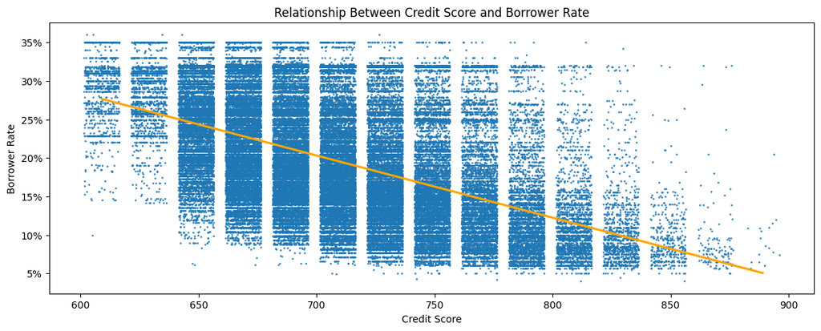

```python
# Define the to_percentage function
def to_percentage(y, position):
    # Convert to percentage
    return f'{y * 100:.0f}%'

# set plot dimensions
plt.figure(figsize=(14,5))

sns.regplot(data=df_clean, x='CreditScore', y='BorrowerRate', x_jitter=7.5, scatter_kws={'s':1}, line_kws={'color':'orange'})
plt.xlabel('Credit Score')
plt.ylabel('Borrower Rate')
plt.title('Relationship Between Credit Score and Borrower Rate')
plt.gca().yaxis.set_major_formatter(FuncFormatter(to_percentage));
```

### Observation

- The scatter plot with the regression line shows a clear negative relationship between Credit Score and BorrowerRate.
- As the credit score increases, the borrower rate generally decreases, indicating that borrowers with higher credit scores are charged lower interest rates.
- The points are spread around the regression line, showing some variability, but the overall trend is consistent.
- This relationship aligns with expectations, as higher credit scores typically indicate lower risk, resulting in lower interest rates for borrowers.

### Question

How do borrower rates (interest rates) vary across different loan terms?

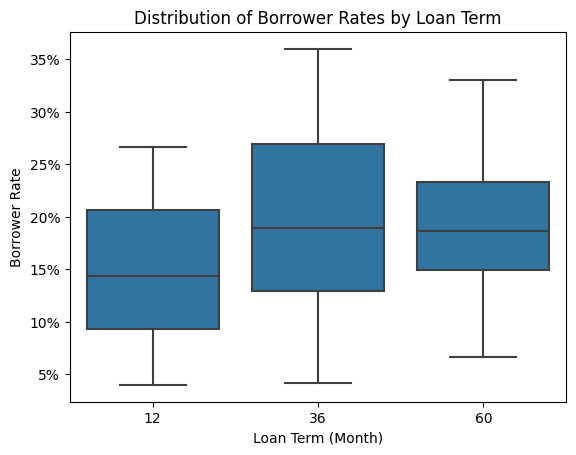

```python
# Create a box plot to visualize the distribution of Borrower Rates by Loan Term
sns.boxplot(data=df_clean, x='Term', y='BorrowerRate', color='tab:blue')

# Labeling the x-axis as 'Loan Term (Month)'
plt.xlabel('Loan Term (Month)')

# Labeling the y-axis as 'Borrower Rate'
plt.ylabel('Borrower Rate')

# Formatting the y-axis to display percentages
from matplotlib.ticker import FuncFormatter

def to_percentage(y, position):
    # Converts a number to a percentage format
    return f'{y * 100:.0f}%'

# Adding a title to the box plot
plt.title('Distribution of Borrower Rates by Loan Term')

# Apply the percentage format to the y-axis
plt.gca().yaxis.set_major_formatter(FuncFormatter(to_percentage));
```

### Observation

- The box plot shows the distribution of borrower rates across different loan terms (12 months, 36 months, 60 months).
- For 12-month loans, the borrower rates are relatively lower with a median around 15%, and the interquartile range (IQR) is narrow, indicating less variability.
- For 36-month loans, the borrower rates are higher, with a median around 20%, and the IQR is wider, indicating more variability and the presence of some higher interest rates.
- For 60-month loans, the median borrower rate is very close to 36-month loans with narrower interquartile range (IQR). This indicates moderate variability and more consistent rates compared to 36-month loans.
- This pattern suggests that lenders charge higher interest rates for 36-month and 60-month loans due to the higher risk associated with a longer payback period. The lower variability in the 60-month loan rates could be due to stricter lending criteria or a more selective borrower pool, resulting in more consistent risk assessments and interest rates.

### Question

How does the distribution of Prosper Ratings differ between homeowners and non-homeowners?

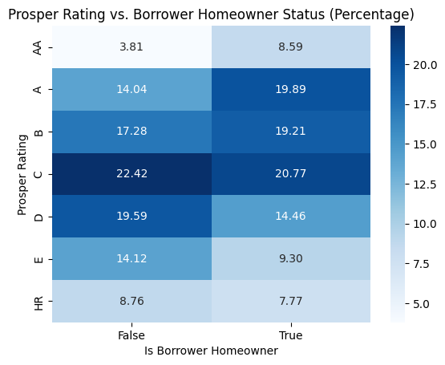

```python
# Grouping the data and creating a pivot table
ct_counts = df_clean.groupby(['ProsperRating (Alpha)', 'IsBorrowerHomeowner']).size().reset_index(name='count')
ct_counts = ct_counts.pivot(index='ProsperRating (Alpha)', columns='IsBorrowerHomeowner', values='count')

# Calculating the percentage for each column
ct_counts_percentage = ct_counts.div(ct_counts.sum(axis=0), axis=1) * 100

# Creating the heatmap
sns.heatmap(ct_counts_percentage, annot=True, fmt='.2f', cmap='Blues')
plt.xlabel('Is Borrower Homeowner')
plt.ylabel('Prosper Rating')
plt.title('Prosper Rating vs. Borrower Homeowner Status (Percentage)');
```

### Observation

- The heatmap shows the percentage distribution of Prosper Ratings between homeowners and non-homeowners.
- Homeowners generally have higher percentages in the better Prosper Ratings (AA, A, B), indicating lower risk profiles compared to non-homeowners. For instance, 8.59% of homeowners have an AA rating compared to 3.81% of non-homeowners. Similarly, homeowners have higher percentages in A and B ratings.
- Non-homeowners have higher percentages in the lower Prosper Ratings (C, D, E, HR), suggesting higher risk profiles. For example, 22.42% of non-homeowners have a C rating compared to 20.77% of homeowners. Non-homeowners also have higher percentages in D and E ratings.
- The trend indicates that homeownership is associated with better credit ratings, reflecting more financial stability and lower perceived risk by lenders.

### Relationships Between Features of Interest and Other Features

**BorrowerRate and CreditScore**

BorrowerRate is inversely related to CreditScore in the dataset. Borrowers with higher credit scores are charged lower borrower rates, reflecting their lower risk profile. Higher credit scores indicate better creditworthiness, resulting in more favorable loan terms for these borrowers. Conversely, borrowers with lower credit scores face higher borrower rates. This reflects the higher risk perceived by lenders, as lower credit scores suggest a greater likelihood of default. This inverse relationship underscores the importance of maintaining a high credit score to secure better loan terms and lower interest rates.

**BorrowerRate and Term**

BorrowerRate varies significantly with the loan Term. Short-term loans (12 months) typically have lower borrower rates, with a median around 15%, indicating that shorter repayment periods are seen as less risky by lenders. Medium-term loans (36 months) show higher borrower rates, with a median around 20%, and greater variability, reflecting the increased risk associated with these loans. Long-term loans (60 months) have a median borrower rate which is very close to 36-month loans but less variability. This suggests that while long-term loans are riskier, they benefit from a balance between interest rates and repayment period, potentially due to more stringent lending criteria.

**Prosper Rating and Homeownership**

Prosper Rating significantly varies with Homeownership status. Homeowners generally have better Prosper Ratings (AA, A, B), reflecting their financial stability and lower risk profile. For instance, 8.59% of homeowners have an AA rating compared to only 3.81% of non-homeowners. Non-homeowners, on the other hand, tend to have lower Prosper Ratings (C, D, E, HR), indicating higher perceived risk. The absence of homeownership is seen as a higher risk factor, resulting in lower credit ratings. This relationship highlights the impact of homeownership on creditworthiness, with homeowners typically enjoying higher credit ratings and more favorable lending terms.

## Multivariate Exploration

Display the first few rows of the clean dataset to get an initial overview

```python
# Display the first few rows of the clean dataset to get an initial overview
df_clean.head()
```

|  | ListingKey | Term | BorrowerRate | ProsperRating (Alpha) | IsBorrowerHomeowner | CreditScore |
| --- | --- | --- | --- | --- | --- | --- |
| 0 | 10273602499503308B223C1 | 36 | 0.0920 | A | False | 689 |
| 1 | 0EF5356002482715299901A | 36 | 0.0974 | A | True | 809 |
| 2 | 0F023589499656230C5E3E2 | 36 | 0.2085 | D | True | 689 |
| 3 | 0F05359734824199381F61D | 60 | 0.1314 | B | True | 749 |
| 4 | 0F0A3576754255009D63151 | 36 | 0.2712 | E | False | 689 |

### Question

How does the Borrower Rate vary across different loan terms for homeowners and non-homeowners?

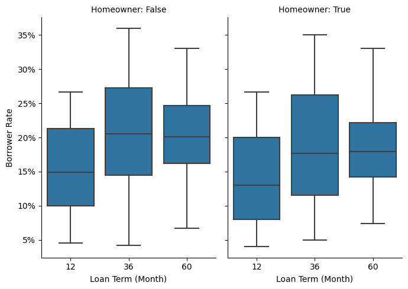

```python
# Determine the unique values for 'Term' to specify the order
term_order = sorted(df_clean['Term'].unique())

# Creating the FacetGrid
g_1 = sns.FacetGrid(data=df_clean, col='IsBorrowerHomeowner', height=5, aspect=0.7)
g_1.map(sns.boxplot, 'Term', 'BorrowerRate', order=term_order, color='tab:blue')

# Formatting the y-axis to display percentages
def to_percentage(y, position):
    # Converts a number to a percentage format
    return f'{y * 100:.0f}%'

for ax in g_1.axes.flatten():
    ax.yaxis.set_major_formatter(FuncFormatter(to_percentage))

# Customizing the facet titles
g_1.set_titles(col_template='Homeowner: {col_name}')

# Adding the titles
g_1.set_axis_labels('Loan Term (Month)', 'Borrower Rate');
```

### Observation

**Homeowners**

**Non-Homeowners**

- 12-Month Loans: With a median borrower rate around 15%. The interquartile range (IQR) ranges from 10% to 22%.
- 36-Month Loans: With a median borrower rate around 21%. The interquartile range (IQR) ranges from 15% to 27%.
- 60-Month Loans: With a median borrower rate around 20%. The interquartile range (IQR) ranges from 16% to 25%.

### Question

How does the Borrower Rate vary with Credit Score for borrowers with different homeownership statuses (Homeowner vs. Non-Homeowner)?

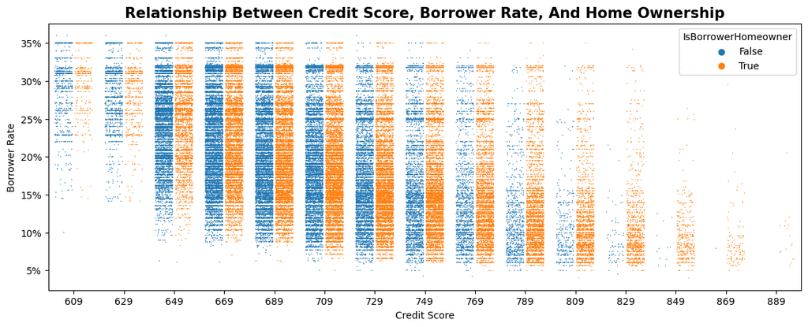

```python
# Define the to_percentage function
def to_percentage(y, position):
    # Convert y-axis values to percentage format
    return f'{y * 100:.0f}%'

# Set plot dimensions to 14 inches by 5 inches
plt.figure(figsize=(14,5))

sns.stripplot(data=df_clean,
              x='CreditScore', y='BorrowerRate', hue='IsBorrowerHomeowner',
              size=1, jitter=0.35, dodge=True)

# Set the title of the plot with customized font size and weight
plt.title('Relationship between Credit Score, Borrower Rate, and home ownership'.title(), fontsize=15, fontweight='bold')

# Set the x-axis label and capitalize it
plt.xlabel('Credit Score'.title())

# Set the y-axis label and capitalize it
plt.ylabel('Borrower Rate'.title())

# Apply the percentage formatter to the y-axis
plt.gca().yaxis.set_major_formatter(FuncFormatter(to_percentage))

# Display the plot
plt.show();
```

### Observation

**Relationship with Credit Score**: For both homeowners and non-homeowners, borrower rates generally decrease as credit scores increase. This indicates that higher credit scores, which suggest better creditworthiness, result in lower interest rates for both groups.

**Credit Score Distribution**: Homeowners tend to have better credit scores than non-homeowners overall. This is partly due to mortgage payments which build up credit scores and indicate better financial stability. The scatter plot shows a higher concentration of homeowners with credit scores above 700 compared to non-homeowners.

**Borrower Rate Differences**: For credit scores under 680, homeowners benefit from lower borrower rates compared to non-homeowners due to the collateral provided by homeownership. Between 680 and 720, borrower rates are similar for both groups, indicating a more uniform risk assessment by lenders. For credit scores over 720, non-homeowners enjoy lower borrower rates, potentially due to their good credit history without mortgage burdens, leading to better financial conditions and lower perceived risk.

### Surprising Interactions

- It was surprising to find that non-homeowners with high credit scores (above 720) receive lower borrower rates than homeowners with the same credit score. This suggests that lenders may place a higher value on an excellent credit history and financial management skills over the presence of collateral (homeownership) in these cases. This challenges the conventional wisdom that homeownership is always a primary factor in securing the best loan terms.
- Another surprising interaction was the minimal difference in borrower rates between homeowners and non-homeowners for mid-range credit scores (680-720). This indicates that in this range, credit score alone is a strong predictor of risk, and the additional factor of homeownership does not significantly influence the borrower rates. This uniformity suggests that lenders may have a more standardized approach to assessing risk for borrowers in this credit score bracket, regardless of their homeownership status.

## Conclusions

### General Observations

**Loan Term Distribution**

- Majority of loans have a term length of 36 months, followed by 60 months, with a small number of 12-month loans. This indicates a preference for medium-term loans and long-term loans.
- The low count of 12-month loans suggests borrowers prefer longer terms to reduce monthly payments despite higher total interest costs.
- The substantial number of 60-month loans indicates borrower comfort with longer-term commitments, reducing monthly burden.

**Borrower Rate Distribution**

- The histogram of borrower rates shows a range from approximately 0.04 to 0.36, with noticeable peaks around specific values.
- Most borrower rates cluster between 0.10 and 0.26, indicating common interest rates among borrowers.

**Prosper Rating Distribution**

- The most common Prosper Ratings are 'A', 'B', 'C', and 'D', while 'AA' and 'HR' are least common, suggesting fewer very low-risk and very high-risk loans on the Prosper platform.

**Homeownership Status**

- Slightly more homeowners than non-homeowners in the dataset, providing insights into how homeownership affects borrowing behavior and loan performance.

**Credit Score Distribution**

- Majority of borrowers have credit scores between 650 and 775, with a peak around 675-700. Fewer borrowers have scores above 800 or below 650, showing a right-skewed distribution with a long tail towards higher scores.

**Unusual Points & Transformations**

- No unusual points observed. Credit scores were transformed by averaging CreditScoreRangeLower and CreditScoreRangeUpper into a single column for simplicity and better analysis.

### Detailed Observations and Relationships

**Borrower Rate and Credit Score**

- Borrower rates generally decrease as credit scores increase, indicating lower risk for higher credit scores. This relationship is consistent for both homeowners and non-homeowners, emphasizing the importance of maintaining a high credit score.

**Borrower Rate and Loan Term**

- Short-term loans (12 months) have lower borrower rates with less variability. Medium-term loans (36 months) show higher and more variable rates. Long-term loans (60 months) have rates close to 36-month loans but with less variability, suggesting stringent lending criteria for long-term loans.

**Prosper Rating and Homeownership**

- Homeowners have better Prosper Ratings (AA, A, B) reflecting financial stability and lower risk. Non-homeowners have lower ratings (C, D, E, HR), indicating higher perceived risk. Homeownership is associated with better credit ratings and more favorable lending terms.

**Credit Scores and Borrower Rate for Homewoners vs. Non-Homeowners**

- Homeowners generally receive lower borrower rates, particularly for credit scores under 680, due to the additional security provided by their homes.
- Non-Homeowners face higher borrower rates overall, but those with high credit scores (> 720) can receive lower rates than their homeowner counterparts, likely due to their excellent credit history and better financial conditions without the burden of mortgage payments.
- For mid-range credit scores (680-720), there is minimal difference in borrower rates between homeowners and non-homeowners, suggesting that lenders assess risk similarly in this range.

### Final Thoughts

In conclusion, our data analysis reveals intricate relationships between borrower rates, credit scores, loan terms, and homeownership status. Homeownership provides a significant advantage for borrowers, particularly those with lower credit scores, by offering lower borrower rates due to the perceived stability and collateral. Surprisingly, non-homeowners with high credit scores can secure even lower borrower rates than homeowners, highlighting the importance of excellent credit history and financial management. The consistent inverse relationship between credit scores and borrower rates underscores the critical role of creditworthiness in securing favorable loan terms. These insights emphasize the importance of maintaining a high credit score and understanding the impact of homeownership on lending decisions. This comprehensive analysis equips borrowers with valuable knowledge to navigate the loan landscape and enables lenders to make informed risk assessments.